# Rmarkdown example

Nicholas Tierney

```r
library(tidyverse)
```

# Introduction

This is a simple analysis of the New York Air Quality Measurements using the R statistical programming language (R Core Team 2017). As stated in the helpfile `?airquality`, this dataset contains:

> Daily air quality measurements in New York, May to September 1973.

And the dataset is sourced from:

> … the New York State Department of Conservation (ozone data) and the National Weather Service (meteorological data).

It contains the following variables

- Ozone: Mean ozone in parts per billion from 1300 to 1500 hours at Roosevelt Island.
- Solar.R: Solar radiation in Langleys in the frequency band 4000–7700 Angstroms from 0800 to 1200 hours at Central Park.
- Wind: Average wind speed in miles per hour at 0700 and 1000 hours at LaGuardia Airport.
- Temp: Maximum daily temperature in degrees Fahrenheit at La Guardia Airport.
- Month: Month (1–12)
- Day: Day of month (1–31)

# Method

First, we tidy the names of the dataset, to provide information about the units of measurement for Ozone, Solar Radiation, Wind, and Temperature. We do this by renaming the variables and adding a suffix at the end to describe the units. To do this we use the `rename` function from the `dplyr` package(Wickham et al. 2017).

```r
tidy_aq <-rename(.data = airquality,
                 ozone_ppb = Ozone,
                 solar_rad_lang = Solar.R,
                 wind_mph = Wind,
                 temp_fah = Temp,
                 month = Month,
                 day = Day)
```

We can see that there is an interesting relationship between ozone and solar radiation in figure 1 below, plotted using ggplot2 (Wickham and Chang 2017)

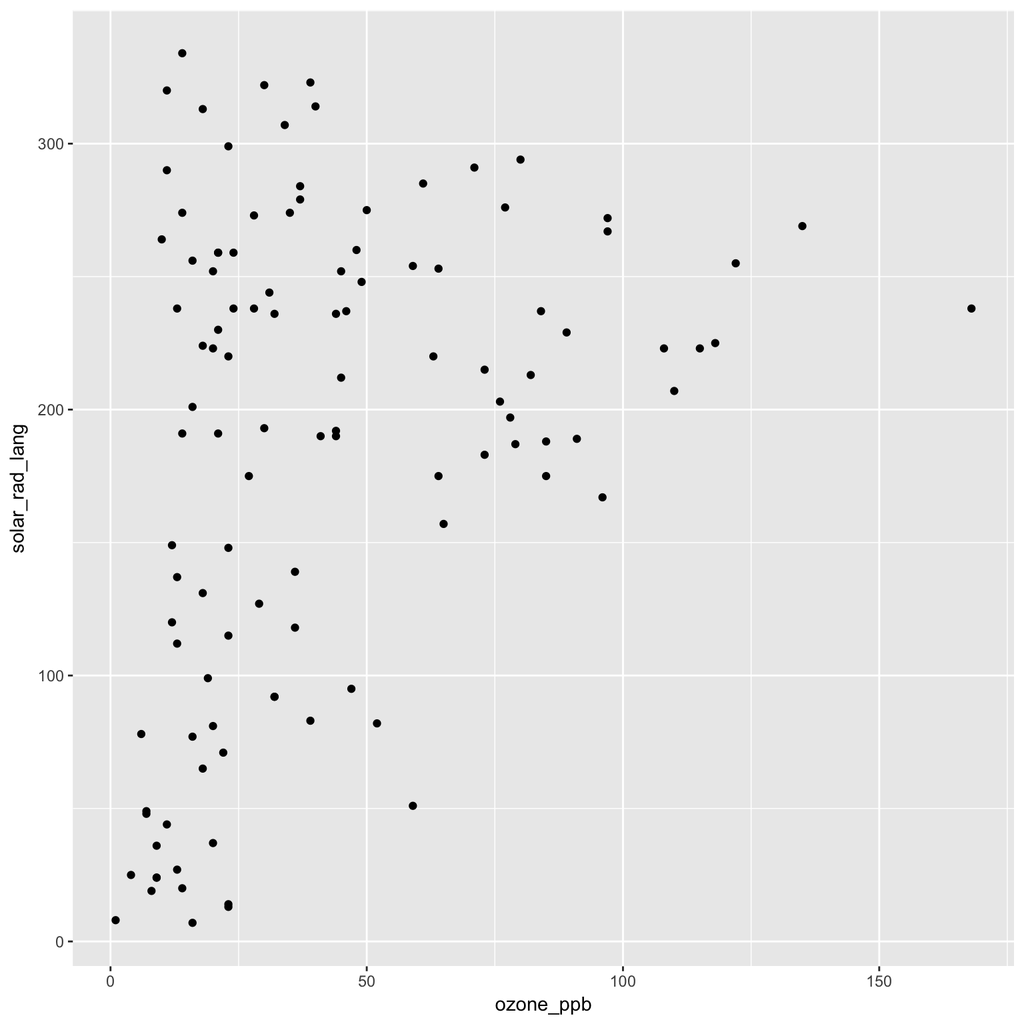

```r
ggplot(tidy_aq,
       aes(x = ozone_ppb,
           y = solar_rad_lang)) +
  geom_point()
```

We can also see that there is an interesting relationship between Ozone and temperature.

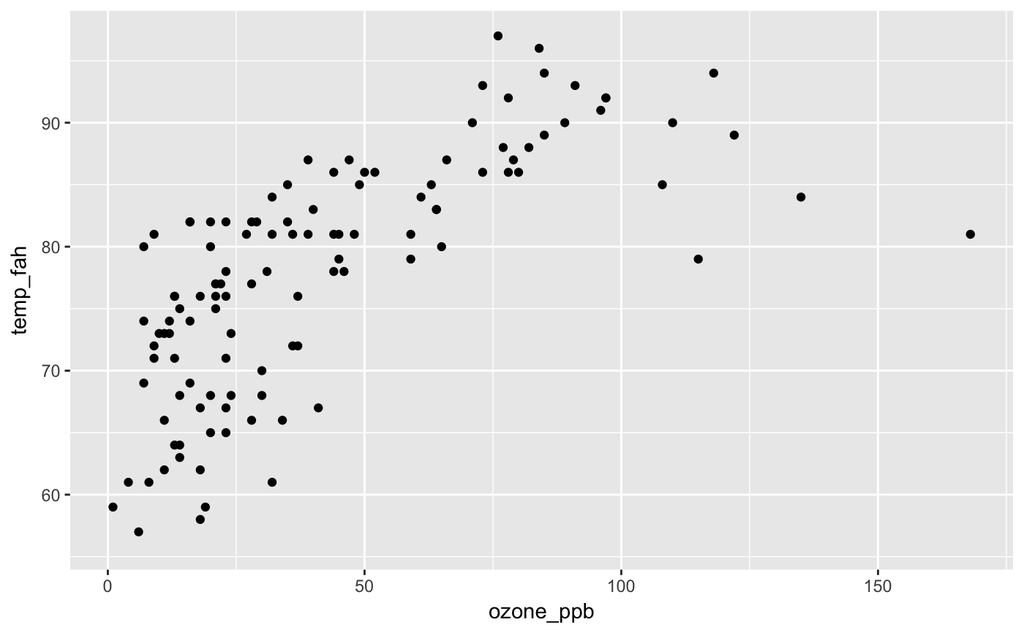

```r
ggplot(tidy_aq,
       aes(x = ozone_ppb,
           y = temp_fah)) +
  geom_point()
```

$$Ozone \sim \beta_0 + \beta_1Solar + \beta_2 Wind + \beta_3Temp + \epsilon$$

And we can fit this model using the code below.

```r
lm_aq <- lm(ozone_ppb ~ solar_rad_lang + wind_mph + temp_fah,
            data = tidy_aq)
```

# Results

The key results are given below, using the `tidy` function from the `broom` package (Robinson 2017) to clean up the data.

```r
library(broom)
tidy_lm_aq <- tidy(lm_aq)
tidy_lm_aq
```

| term | estimate | std.error | statistic | p.value |
| --- | --- | --- | --- | --- |
| (Intercept) | -64.34207893 | 23.05472435 | -2.790841 | 6.226638e-03 |
| solar_rad_lang | 0.05982059 | 0.02318647 | 2.579979 | 1.123664e-02 |
| wind_mph | -3.33359131 | 0.65440710 | -5.094063 | 1.515934e-06 |
| temp_fah | 1.65209291 | 0.25352979 | 6.516366 | 2.423506e-09 |

We can present this result in a nice table using the `kable` function from the knitr package (Xie 2017)

```r
knitr::kable(tidy_lm_aq,
             digits = 3,
             caption = "Table of results from the linear model")
```

| term | estimate | std.error | statistic | p.value |
| --- | --- | --- | --- | --- |
| (Intercept) | -64.342 | 23.055 | -2.791 | 0.006 |
| solar_rad_lang | 0.060 | 0.023 | 2.580 | 0.011 |
| wind_mph | -3.334 | 0.654 | -5.094 | 0.000 |
| temp_fah | 1.652 | 0.254 | 6.516 | 0.000 |

We can also refer to individual results of the model inside the text. For example, we can say that the estimated coefficient of Wind miles per hour is -3.334, and the P value of this is 0.

# Conclusion

We have explored the relationship of Ozone with other variables in the airquality dataset

# References

R Core Team. 2017. *R: A Language and Environment for Statistical Computing*. Vienna, Austria: R Foundation for Statistical Computing. https://www.R-project.org/.

Robinson, David. 2017. *Broom: Convert Statistical Analysis Objects into Tidy Data Frames*. https://CRAN.R-project.org/package=broom.

Wickham, Hadley, and Winston Chang. 2017. *Ggplot2: Create Elegant Data Visualisations Using the Grammar of Graphics*.

Wickham, Hadley, Romain Francois, Lionel Henry, and Kirill Müller. 2017. *Dplyr: A Grammar of Data Manipulation*. https://CRAN.R-project.org/package=dplyr.

Xie, Yihui. 2017. *Knitr: A General-Purpose Package for Dynamic Report Generation in R*. https://CRAN.R-project.org/package=knitr.